# Bike Share Data Analysis

```r
install.packages("jupytext")
knitr::opts_chunk$set(jupytext_formats = "ipynb,Rmd")
```

**#1 Popular times of travel** (i.e., occurs most often in the start time)

- **What is the most common month?**
- What is the most common day of week?
- What is the most common hour of day?

**#2 Popular stations and trip**

- What is the most common start station?
- **What is the most common end station?**
- What is the most common trip from start to end (i.e., most frequent combination of start station and end station)?

**#3 Trip duration**

- What is the total travel time for users in different cities?
- What is the average travel time for users in different cities?

**#4 User info**

- What are the counts of each user type?
- What are the counts of each gender (only available for NYC and Chicago)?
- What are the earliest, most recent, most common year of birth (only available for NYC and Chicago)?

```r
install.packages("dplyr","summarytools","lubridate","ggplot2")
```

```
Error in install.packages : Updating loaded packages
```

```r
library(dplyr, summarytools, lubridate, ggplot2)
```

```
Error: object 'ggplot2' not found
```

```r
current_datetime <- Sys.time()
formatted_date <- format(current_datetime, "%Y-%m-%d %H:%M:%S")

cat("Chunk completed on:", format(current_datetime, "%Y-%m-%d %H:%M:%S"), "\n")
```

```
Chunk completed on: 2023-10-10 08:52:23
```

## Load, Inspect, and Clean the Data

```r
ny = read.csv("new-york-city.csv")
wash = read.csv("washington.csv")
chi = read.csv("chicago.csv")

cat("Chunk completed on:", format(Sys.time(), "%Y-%m-%d %H:%M:%S"), "\n")
```

```
Chunk completed on: 2023-10-10 08:57:05
```

```r
colnames(ny)
```

```
[1] "X"             "Start.Time"    "End.Time"      "Trip.Duration" "Start.Station" "End.Station"
[7] "User.Type"     "Gender"        "Birth.Year"
```

```r
cat("Chunk completed on:", format(Sys.time(), "%Y-%m-%d %H:%M:%S"), "\n")
```

```
Chunk completed on: 2023-10-10 08:57:05
```

```r
colnames(wash)
```

```
[1] "X"             "Start.Time"    "End.Time"      "Trip.Duration" "Start.Station" "End.Station"
[7] "User.Type"
```

```r
cat("Chunk completed on:", format(Sys.time(), "%Y-%m-%d %H:%M:%S"), "\n")
```

```
Chunk completed on: 2023-10-10 08:57:05
```

```r
colnames(chi)
```

```
[1] "X"             "Start.Time"    "End.Time"      "Trip.Duration" "Start.Station" "End.Station"
[7] "User.Type"     "Gender"        "Birth.Year"
```

```r
cat("Chunk completed on:", format(Sys.time(), "%Y-%m-%d %H:%M:%S"), "\n")
```

```
Chunk completed on: 2023-10-10 08:57:05
```

```r
str(ny)
```

```
'data.frame':   300000 obs. of  9 variables:
 $ X            : int  5688089 4096714 2173887 3945638 6208972 1285652 1675753 1692245 2271331 1558339 ...
 $ Start.Time   : chr  "2017-06-11 14:55:05" "2017-05-11 15:30:11" "2017-03-29 13:26:26" "2017-05-08 19:47:18" ...
 $ End.Time     : chr  "2017-06-11 15:08:21" "2017-05-11 15:41:43" "2017-03-29 13:48:31" "2017-05-08 19:59:01" ...
 $ Trip.Duration: int  795 692 1325 703 329 998 478 4038 5132 309 ...
 $ Start.Station: chr  "Suffolk St & Stanton St" "Lexington Ave & E 63 St" "1 Pl & Clinton St" "Barrow St & Hudson St" ...
 $ End.Station  : chr  "W Broadway & Spring St" "1 Ave & E 78 St" "Henry St & Degraw St" "W 20 St & 8 Ave" ...
 $ User.Type    : chr  "Subscriber" "Subscriber" "Subscriber" "Subscriber" ...
 $ Gender       : chr  "Male" "Male" "Male" "Female" ...
 $ Birth.Year   : num  1998 1981 1987 1986 1992 ...
```

```r
cat("Chunk completed on:", format(Sys.time(), "%Y-%m-%d %H:%M:%S"), "\n")
```

```
Chunk completed on: 2023-10-10 08:57:06
```

```r
str(wash)
```

```
'data.frame':   300000 obs. of  7 variables:
 $ X            : int  1621326 482740 1330037 665458 1481135 1148202 1594275 1601832 574182 327058 ...
 $ Start.Time   : chr  "2017-06-21 08:36:34" "2017-03-11 10:40:00" "2017-05-30 01:02:59" "2017-04-02 07:48:35" ...
 $ End.Time     : chr  "2017-06-21 08:44:43" "2017-03-11 10:46:00" "2017-05-30 01:13:37" "2017-04-02 08:19:03" ...
 $ Trip.Duration: num  489 403 637 1827 1549 ...
 $ Start.Station: chr  "14th & Belmont St NW" "Yuma St & Tenley Circle NW" "17th St & Massachusetts Ave NW" "Constitution Ave & 2nd St NW/DOL" ...
 $ End.Station  : chr  "15th & K St NW" "Connecticut Ave & Yuma St NW" "5th & K St NW" "M St & Pennsylvania Ave NW" ...
 $ User.Type    : chr  "Subscriber" "Subscriber" "Subscriber" "Customer" ...
```

```r
cat("Chunk completed on:", format(Sys.time(), "%Y-%m-%d %H:%M:%S"), "\n")
```

```
Chunk completed on: 2023-10-10 08:57:06
```

```r
str(chi)
```

```
'data.frame':   300000 obs. of  9 variables:
 $ X            : int  1423854 955915 9031 304487 45207 1473887 961916 65924 606841 135470 ...
 $ Start.Time   : chr  "2017-06-23 15:09:32" "2017-05-25 18:19:03" "2017-01-04 08:27:49" "2017-03-06 13:49:38" ...
 $ End.Time     : chr  "2017-06-23 15:14:53" "2017-05-25 18:45:53" "2017-01-04 08:34:45" "2017-03-06 13:55:28" ...
 $ Trip.Duration: int  321 1610 416 350 534 586 281 723 689 493 ...
 $ Start.Station: chr  "Wood St & Hubbard St" "Theater on the Lake" "May St & Taylor St" "Christiana Ave & Lawrence Ave" ...
 $ End.Station  : chr  "Damen Ave & Chicago Ave" "Sheffield Ave & Waveland Ave" "Wood St & Taylor St" "St. Louis Ave & Balmoral Ave" ...
 $ User.Type    : chr  "Subscriber" "Subscriber" "Subscriber" "Subscriber" ...
 $ Gender       : chr  "Male" "Female" "Male" "Male" ...
 $ Birth.Year   : num  1992 1992 1981 1986 1975 ...
```

```r
cat("Chunk completed on:", format(Sys.time(), "%Y-%m-%d %H:%M:%S"), "\n")
```

```
Chunk completed on: 2023-10-10 08:57:06
```

### Fix Missing Data

The dataframe ‘wash’ does not have the columns `$Gender` or `$Birth.Year`, which could affect combining the data. Will create some dummy columns to make the shapes the same.

```r
wash$Gender <- NA
wash$Birth.Year <-NA

cat("Chunk completed on:", format(Sys.time(), "%Y-%m-%d %H:%M:%S"), "\n")
```

```
Chunk completed on: 2023-10-10 08:57:06
```

### Fix Data Types

```r
formatDateTimeColumn <- function(df, col_name) {
  # Check if the specified column exists in the dataframe
  if (!col_name %in% colnames(df)) {
    stop("Column not found in the dataframe.")
  }

  # Convert the specified column to POSIXct
  df[[col_name]] <- as.POSIXct(df[[col_name]], format = "%Y-%m-%d %H:%M:%S")

  # Format the column using strftime()
  df[[col_name]] <- strftime(df[[col_name]], format = "%Y-%m-%d %H:%M:%S")

  return(df)
}

cat("Chunk completed on:", format(Sys.time(), "%Y-%m-%d %H:%M:%S"), "\n")
```

```
Chunk completed on: 2023-10-10 08:57:06
```

```r
ny <- formatDateTimeColumn(ny, "Start.Time")
wash <- formatDateTimeColumn(wash, "Start.Time")
chi <- formatDateTimeColumn(chi, "Start.Time")

cat("Chunk completed on:", format(Sys.time(), "%Y-%m-%d %H:%M:%S"), "\n")
```

```
Chunk completed on: 2023-10-10 08:57:13
```

```r
ny <- formatDateTimeColumn(ny, "End.Time")
wash <- formatDateTimeColumn(wash, "End.Time")
chi <- formatDateTimeColumn(chi, "End.Time")

cat("Chunk completed on:", format(Sys.time(), "%Y-%m-%d %H:%M:%S"), "\n")
```

```
Chunk completed on: 2023-10-10 08:57:20
```

### Put it all together and mix it all up

Before I combine my dataframes into one master one, I need to indicate which city/dataset the values come from

```r
ny$City <- "NY"
wash$City <- "Washington"
chi$City <- "Chicago"

cat("Chunk completed on:", format(Sys.time(), "%Y-%m-%d %H:%M:%S"), "\n")
```

```
Chunk completed on: 2023-10-10 08:57:20
```

```r
merged_df <-rbind(ny,wash)
merged_df <- rbind(merged_df,chi)
cat("Chunk completed on:", format(Sys.time(), "%Y-%m-%d %H:%M:%S"), "\n")
```

```
Chunk completed on: 2023-10-10 08:57:21
```

```r
head(merged_df)
```

|  | X | Start.Time | End.Time | Trip.Duration | Start.Station | End.Station | User.Type | Gender | Birth.Year | City |
| --- | --- | --- | --- | --- | --- | --- | --- | --- | --- | --- |
| 1 | 5688089 | 2017-06-11 14:55:05 | 2017-06-11 15:08:21 | 795 | Suffolk St & Stanton St | W Broadway & Spring St | Subscriber | Male | 1998 | NY |
| 2 | 4096714 | 2017-05-11 15:30:11 | 2017-05-11 15:41:43 | 692 | Lexington Ave & E 63 St | 1 Ave & E 78 St | Subscriber | Male | 1981 | NY |
| 3 | 2173887 | 2017-03-29 13:26:26 | 2017-03-29 13:48:31 | 1325 | 1 Pl & Clinton St | Henry St & Degraw St | Subscriber | Male | 1987 | NY |
| 4 | 3945638 | 2017-05-08 19:47:18 | 2017-05-08 19:59:01 | 703 | Barrow St & Hudson St | W 20 St & 8 Ave | Subscriber | Female | 1986 | NY |
| 5 | 6208972 | 2017-06-21 07:49:16 | 2017-06-21 07:54:46 | 329 | 1 Ave & E 44 St | E 53 St & 3 Ave | Subscriber | Male | 1992 | NY |
| 6 | 1285652 | 2017-02-22 18:55:24 | 2017-02-22 19:12:03 | 998 | State St & Smith St | Bond St & Fulton St | Subscriber | Male | 1986 | NY |

# **Questions:**

## **#1 Popular times of travel** (i.e., occurs most often in the start time)

- What is the most common month?

```r
# Extract the month from the 'Start.Time' column. Will need lubridate
merged_df$Start.Month <- month(merged_df$Start.Time)

# Calculate the mode (most common) month
mode_month <- as.integer(names(sort(table(merged_df$Start.Month), decreasing = TRUE)[1]))

# Convert the mode_month to a month name
mode_month_name <- month.name[mode_month]

# Print the result
cat("The most common month is:", mode_month_name, "\n")
```

```
The most common month is: June
```

```r
# Extract the month from the 'Start.Time' column
merged_df$Start.Month <- month(merged_df$Start.Time)

# Create separate dataframes for each city
ny_data <- merged_df %>% filter(City == "NY")
wash_data <- merged_df %>% filter(City == "Washington")
chi_data <- merged_df %>% filter(City == "Chicago")

# Create plots for each city
ny_data <- ggplot(ny_data, aes(x = Start.Month)) +
  geom_bar() +
  labs(title = "New York - Rides per Month", x = "Month", y = "Count")

wash_data <- ggplot(wash_data, aes(x = Start.Month)) +
  geom_bar() +
  labs(title = "Washington - Rides per Month", x = "Month", y = "Count")

chi_data <- ggplot(chi_data, aes(x = Start.Month)) +
  geom_bar() +
  labs(title = "Chicago - Rides per Month", x = "Month", y = "Count")

cat("Chunk completed on:", format(Sys.time(), "%Y-%m-%d %H:%M:%S"), "\n")
```

```
Chunk completed on: 2023-10-10 08:58:28
```

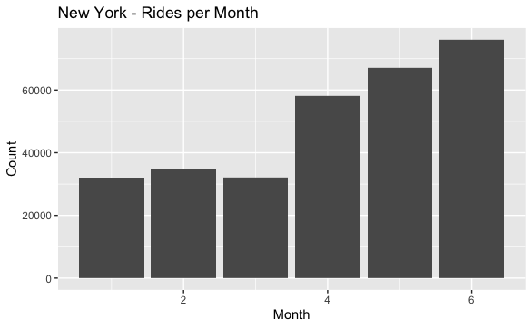

```r
# Print the plots
print(ny_data)
```

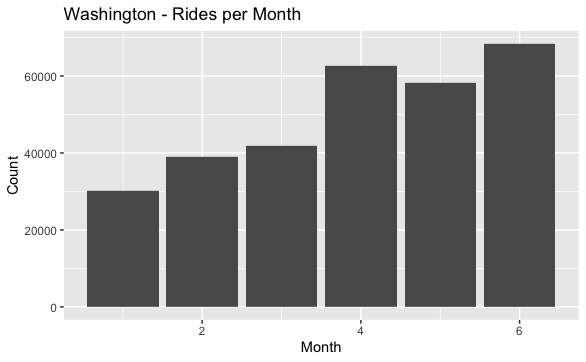

```r
print(wash_data)
```

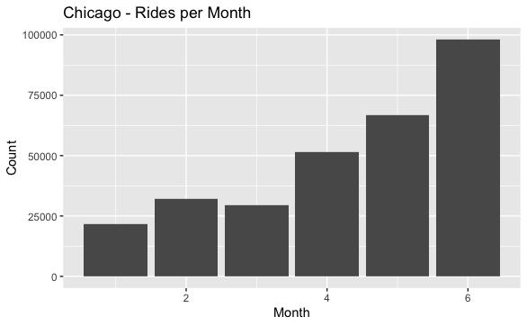

```r
print(chi_data)
```

Summary: The dataset indicates that June is the most popular month, which could indicate an increase in ridership for the summer time; however after visualizing, it looks like we are limited to just the first half of the year, so this assumption could be wrong.

## **#2 Popular stations and trip**

```r
# Use the table() function to count the occurrences of each end station
end_station_counts <- table(merged_df$End.Station)

# Sort the counts in descending order
sorted_counts <- sort(end_station_counts, decreasing = TRUE)

# Get the top 10 most common end stations
top_10_end_stations <- head(sorted_counts, 10)

cat("Chunk completed on:", format(Sys.time(), "%Y-%m-%d %H:%M:%S"), "\n")
```

```
Chunk completed on: 2023-10-10 08:58:29
```

```r
# Print the result
# print(top_10_end_stations)
```

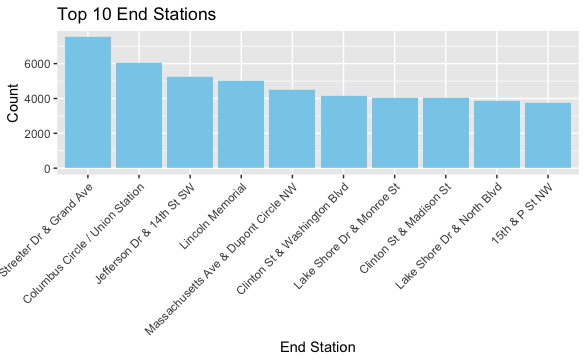

```r
station_data <-as.data.frame(top_10_end_stations)
colnames(station_data) <- c("End_Station","Count")


# Show the results
ggplot(station_data, aes(x = reorder(End_Station, -Count), y = Count)) +
  geom_bar(stat = "identity", fill = "skyblue") +
  labs(x = "End Station", y = "Count") +
  ggtitle("Top 10 End Stations") +
  theme(axis.text.x = element_text(angle = 45, hjust = 1))
```

```r
cat("Chunk completed on:", format(Sys.time(), "%Y-%m-%d %H:%M:%S"), "\n")
```

```
Chunk completed on: 2023-10-10 08:58:29
```

Let’s get more complicated, let’s graph by City, as well:

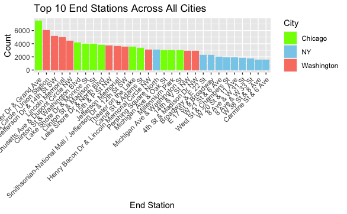

```r
top_stations <- merged_df %>%
  group_by(City, End.Station) %>%
  summarize(Count = n()) %>%
  arrange(City, desc(Count)) %>%
  group_by(City) %>%
  top_n(10, wt = Count)
# Create a bar plot with bars colored by City and a legend
ggplot(top_stations, aes(x = reorder(End.Station, -Count), y = Count, fill = City)) +
  geom_bar(stat = "identity", position = "dodge") +
  labs(x = "End Station", y = "Count") +
  ggtitle("Top 10 End Stations Across All Cities") +
  theme(axis.text.x = element_text(angle = 45, hjust = 1)) +
  scale_fill_manual(values = c("NY" = "skyblue", "Washington" = "salmon", "Chicago" = "chartreuse")) +
  guides(fill = guide_legend(title = "City"))
```

```r
cat("Chunk completed on:", format(Sys.time(), "%Y-%m-%d %H:%M:%S"), "\n")
```

```
Chunk completed on: 2023-10-10 08:58:29
```

## **#4 User info**

- What are the earliest, most recent, most common year of birth (only available for NYC and Chicago)?

```r
# Load the necessary library (if not already loaded)
# install.packages("dplyr") # Uncomment this line if you haven't installed dplyr
library(dplyr)

# Assuming your dataframe is named 'merged_df'

# Remove missing or invalid birth years (if any)
merged_df <- merged_df %>%
  filter(!is.na(Birth.Year) & Birth.Year >= 1900)

# Find the earliest birth year
earliest_birth_year <- min(merged_df$Birth.Year)

# Find the most recent birth year
most_recent_birth_year <- max(merged_df$Birth.Year)

# Find the most common birth year
most_common_birth_year <- merged_df %>%
  group_by(Birth.Year) %>%
  summarize(Count = n()) %>%
  arrange(desc(Count)) %>%
  slice(1) %>%
  pull(Birth.Year)

# Print the results
cat("Earliest birth year:", earliest_birth_year, "\n")
```

```
Earliest birth year: 1900
```

```r
cat("Most recent birth year:", most_recent_birth_year, "\n")
```

```
Most recent birth year: 2016
```

```r
cat("Most common birth year:", most_common_birth_year, "\n")
```

```
Most common birth year: 1989
```

```r
cat("Chunk completed on:", format(Sys.time(), "%Y-%m-%d %H:%M:%S"), "\n")
```

```
Chunk completed on: 2023-10-10 08:58:30
```